# Taller 9

Métodos Computacionales para Políticas Públicas - URosario

**Entrega: viernes 28-oct-2016 11:59 PM**

**[Camila Valencia]**  
[camilavalenciar@gmail.com]

## Instrucciones:

- Guarde una copia de este *Jupyter Notebook* en su computador, idealmente en una carpeta destinada al material del curso.
- Modifique el nombre del archivo del *notebook*, agregando al final un guión inferior y su nombre y apellido, separados estos últimos por otro guión inferior. Por ejemplo, mi *notebook* se llamaría: mcpp_taller9_santiago_matallana
- Marque el *notebook* con su nombre y e-mail en el bloque verde arriba. Reemplace el texto "[Su nombre acá]" con su nombre y apellido. Similar para su e-mail.
- Desarrolle la totalidad del taller sobre este *notebook*, insertando las celdas que sea necesario debajo de cada pregunta. Haga buen uso de las celdas para código y de las celdas tipo *markdown* según el caso.
- Recuerde salvar periódicamente sus avances.
- Cuando termine el taller:
  1. Descárguelo en PDF. Si tiene algún problema con la conversión, descárguelo en HTML.
  2. Suba todos los archivos a su repositorio en GitHub, en una carpeta destinada exclusivamente para este taller, antes de la fecha y hora límites.

NLTK Book (http://www.nltk.org/book/), Exercises:

- Chapter 1: 22, 26, 28
- Chapter 2: 2, 4, 11

```python
%matplotlib inline
import matplotlib.pyplot as plt
plt.rcParams["figure.figsize"] = [18.0, 8.0]
```

```python
import nltk
```

```python
from nltk.book import *
```

```
*** Introductory Examples for the NLTK Book ***
Loading text1, ..., text9 and sent1, ..., sent9
Type the name of the text or sentence to view it.
Type: 'texts()' or 'sents()' to list the materials.
text1: Moby Dick by Herman Melville 1851
text2: Sense and Sensibility by Jane Austen 1811
text3: The Book of Genesis
text4: Inaugural Address Corpus
text5: Chat Corpus
text6: Monty Python and the Holy Grail
text7: Wall Street Journal
text8: Personals Corpus
text9: The Man Who Was Thursday by G . K . Chesterton 1908
```

## Chapter 1

##### 22. Find all the four-letter words in the Chat Corpus (text5). With the help of a frequency distribution (FreqDist), show these words in decreasing order of frequency.

```python
L = list(text5)
```

```python
four_words = [w for w in L if len(w) == 4]
four_words
```

```
['left',
 'with',
 'this',
 'name',
 'PART',
 'well',
 'NICK',
 'name',
 'U121',
 'golf',
 'clap',
 'JOIN',
 'that',
 'nice',
 'JOIN',
 'PART',
 'golf',
 'clap',
 'fuck',
 'U121',
 'PART',
 'PART',
 'clap',
 'your',
 'PART',
 'dont',
 'even',
 'know',
 'what',
 'that',
 'that',
 'chat',
 'JOIN',
 'drew',
 'cast',
 'PART',
 'sexy',
 'U115',
 'JOIN',
 'PART',
```

[output cut: 946 more lines]

```
 'even',
 'from',
 'JOIN',
 'cool',
 'sexy',
 'JOIN',
 'sexy',
 'only',
 'none',
 'sexy',
 'whew',
 'sexy',
 'hell',
 'have',
 ...]
```

```python
frecuencia = FreqDist(four_words)
frecuencia
```

```
FreqDist({'plus': 1,
          'U115': 36,
          "yw's": 1,
          'AKDT': 3,
          'hide': 1,
          'MORE': 1,
          'o.k.': 1,
          'post': 1,
          'icky': 1,
          'love': 60,
          'Tiff': 1,
          'tips': 1,
          'bout': 12,
          'Girl': 1,
          'then': 40,
          'puff': 4,
          'U105': 35,
          'MODE': 41,
          'howz': 2,
          'boed': 1,
          'Your': 3,
          'Fort': 1,
          'zone': 2,
          'legs': 5,
          'hehe': 12,
          'numb': 1,
          'yeah': 75,
          'dust': 1,
          '??!!': 2,
          'star': 1,
          'tlak': 1,
          'cash': 2,
          'menu': 1,
          'That': 7,
          'sits': 15,
          'JUST': 1,
          'comp': 6,
          'Drew': 2,
          'joke': 5,
          'hard': 10,
```

[output cut: 946 more lines]

```
          'Ahhh': 2,
          "RN's": 1,
          'Kold': 1,
          'FINE': 1,
          'inch': 1,
          "<3's": 1,
          'shit': 17,
          'clue': 2,
          'mass': 2,
          'team': 4,
          'caan': 1,
          'Rofl': 1,
          'guns': 1,
          'herE': 1,
          ...})
```

```python
import operator
frecuencia_ordenada = sorted(frecuencia.items(), key=operator.itemgetter(1))
frecuencia_ordenada
```

```
[('plus', 1),
 ('toop', 1),
 ('U147', 1),
 ('HUGE', 1),
 ('hiom', 1),
 ('thnx', 1),
 ('hide', 1),
 ('geez', 1),
 ("pm's", 1),
 ('MORE', 1),
 ('o.k.', 1),
 ('post', 1),
 ('icky', 1),
 ('cops', 1),
 ('poof', 1),
 ("PM's", 1),
 ('Girl', 1),
 ('jeep', 1),
 ('NTMN', 1),
 ('poop', 1),
 ('shup', 1),
 ('Hugs', 1),
 ('ssid', 1),
 ('syck', 1),
 ('kong', 1),
 ('card', 1),
 ('fawk', 1),
 ('slam', 1),
 ("yw's", 1),
 ('evah', 1),
 ('HAHA', 1),
 ('Ohhh', 1),
 ('wore', 1),
 ('z-ro', 1),
 ('Then', 1),
 ('Fort', 1),
 ('lyin', 1),
 ('LATE', 1),
 ('SSRI', 1),
 ('gret', 1),
```

[output cut: 946 more lines]

```
 ('case', 8),
 ('wife', 8),
 ('wana', 8),
 ('heyy', 8),
 ('lady', 8),
 ('word', 8),
 ('blue', 8),
 ('says', 8),
 ('U139', 8),
 ('type', 9),
 ('hmmm', 9),
 ('soon', 9),
 ('crap', 9),
 ('nick', 9),
 ...]
```

##### 26. What does the following Python code do? sum(len(w) for w in text1) Can you use it to work out the average word length of a text?

```python
a = sum(len(w) for w in text1)
a
```

```
999044
```

```python
b =len(text1)
b
```

```
260819
```

```python
promedio= a/b
promedio
```

```
3.830411128023649
```

###### 28. Define a function percent(word, text) that calculates how often a given word occurs in a text, and expresses the result as a percentage.

```python
def porcentaje(palabra, texto):
    x= texto.count(palabra)
    y= x/len(texto)
    return y
```

```python
porcentaje("whale", text1)
```

```
0.003473673313677301
```

## Chapter 2

##### 2. Use the corpus module to explore austen-persuasion.txt. How many word tokens does this book have? How many word types?

```python
import nltk
nltk.corpus.gutenberg.fileids()
```

```
['austen-emma.txt',
 'austen-persuasion.txt',
 'austen-sense.txt',
 'bible-kjv.txt',
 'blake-poems.txt',
 'bryant-stories.txt',
 'burgess-busterbrown.txt',
 'carroll-alice.txt',
 'chesterton-ball.txt',
 'chesterton-brown.txt',
 'chesterton-thursday.txt',
 'edgeworth-parents.txt',
 'melville-moby_dick.txt',
 'milton-paradise.txt',
 'shakespeare-caesar.txt',
 'shakespeare-hamlet.txt',
 'shakespeare-macbeth.txt',
 'whitman-leaves.txt']
```

```python
persuasion = nltk.corpus.gutenberg.words('austen-persuasion.txt')
len(persuasion)
```

```
98171
```

```python
len(set(persuasion))
```

```
6132
```

##### 4. Read in the texts of the State of the Union addresses, using the state_union corpus reader. Count occurrences of men, women, and people in each document. What has happened to the usage of these words over time?

```python
nltk.corpus.state_union.fileids()
```

```
['1945-Truman.txt',
 '1946-Truman.txt',
 '1947-Truman.txt',
 '1948-Truman.txt',
 '1949-Truman.txt',
 '1950-Truman.txt',
 '1951-Truman.txt',
 '1953-Eisenhower.txt',
 '1954-Eisenhower.txt',
 '1955-Eisenhower.txt',
 '1956-Eisenhower.txt',
 '1957-Eisenhower.txt',
 '1958-Eisenhower.txt',
 '1959-Eisenhower.txt',
 '1960-Eisenhower.txt',
 '1961-Kennedy.txt',
 '1962-Kennedy.txt',
 '1963-Johnson.txt',
 '1963-Kennedy.txt',
 '1964-Johnson.txt',
 '1965-Johnson-1.txt',
 '1965-Johnson-2.txt',
 '1966-Johnson.txt',
 '1967-Johnson.txt',
 '1968-Johnson.txt',
 '1969-Johnson.txt',
 '1970-Nixon.txt',
 '1971-Nixon.txt',
 '1972-Nixon.txt',
 '1973-Nixon.txt',
 '1974-Nixon.txt',
 '1975-Ford.txt',
 '1976-Ford.txt',
 '1977-Ford.txt',
 '1978-Carter.txt',
 '1979-Carter.txt',
 '1980-Carter.txt',
 '1981-Reagan.txt',
 '1982-Reagan.txt',
 '1983-Reagan.txt',
```

[output cut: 10 more lines]

```
 '1993-Clinton.txt',
 '1994-Clinton.txt',
 '1995-Clinton.txt',
 '1996-Clinton.txt',
 '1997-Clinton.txt',
 '1998-Clinton.txt',
 '1999-Clinton.txt',
 '2000-Clinton.txt',
 '2001-GWBush-1.txt',
 '2001-GWBush-2.txt',
 '2002-GWBush.txt',
 '2003-GWBush.txt',
 '2004-GWBush.txt',
 '2005-GWBush.txt',
 '2006-GWBush.txt']
```

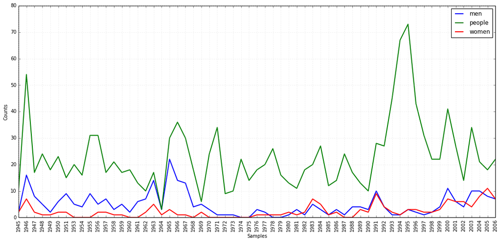

```python
import nltk
from nltk.corpus import state_union
cfd = nltk.ConditionalFreqDist(
    (target, fileid[:4])
    for fileid in state_union.fileids()
    for w in state_union.words(fileid)
    for target in ['men', 'women', 'people']
    if w.lower().startswith(target))
cfd.plot()
```

```python
cfd
```

```
ConditionalFreqDist(nltk.probability.FreqDist,
                    {'men': FreqDist({'1945': 2,
                               '1946': 16,
                               '1947': 8,
                               '1948': 5,
                               '1949': 2,
                               '1950': 6,
                               '1951': 9,
                               '1953': 5,
                               '1954': 4,
                               '1955': 9,
                               '1956': 5,
                               '1957': 7,
                               '1958': 3,
                               '1959': 5,
                               '1960': 2,
                               '1961': 6,
                               '1962': 7,
                               '1963': 14,
                               '1964': 3,
                               '1965': 22,
                               '1966': 14,
                               '1967': 13,
                               '1968': 4,
                               '1969': 5,
                               '1970': 3,
                               '1971': 1,
                               '1972': 1,
                               '1973': 1,
                               '1976': 3,
                               '1977': 2,
                               '1980': 1,
                               '1981': 3,
                               '1982': 1,
                               '1983': 5,
                               '1984': 3,
                               '1985': 1,
                               '1986': 3,
                               '1987': 1,
                               '1988': 4,
```

[output cut: 111 more lines]

```
                               '1992': 4,
                               '1993': 2,
                               '1994': 1,
                               '1995': 3,
                               '1996': 3,
                               '1997': 2,
                               '1998': 2,
                               '1999': 3,
                               '2000': 7,
                               '2001': 6,
                               '2002': 6,
                               '2003': 4,
                               '2004': 8,
                               '2005': 11,
                               '2006': 7})})
```

##### 11. Investigate the table of modal distributions and look for other patterns. Try to explain them in terms of your own impressionistic understanding of the different genres. Can you find other closed classes of words that exhibit significant differences across different genres?

```python
from nltk.corpus import reuters
reuters.categories()
```

```
['acq',
 'alum',
 'barley',
 'bop',
 'carcass',
 'castor-oil',
 'cocoa',
 'coconut',
 'coconut-oil',
 'coffee',
 'copper',
 'copra-cake',
 'corn',
 'cotton',
 'cotton-oil',
 'cpi',
 'cpu',
 'crude',
 'dfl',
 'dlr',
 'dmk',
 'earn',
 'fuel',
 'gas',
 'gnp',
 'gold',
 'grain',
 'groundnut',
 'groundnut-oil',
 'heat',
 'hog',
 'housing',
 'income',
 'instal-debt',
 'interest',
 'ipi',
 'iron-steel',
 'jet',
 'jobs',
 'l-cattle',
```

[output cut: 35 more lines]

```
 'soy-oil',
 'soybean',
 'strategic-metal',
 'sugar',
 'sun-meal',
 'sun-oil',
 'sunseed',
 'tea',
 'tin',
 'trade',
 'veg-oil',
 'wheat',
 'wpi',
 'yen',
 'zinc']
```

```python
cfd = nltk.ConditionalFreqDist(
    (genre, word)
    for genre in reuters.categories()
    for word in reuters.words(categories=genre))
genres = ['fuel', 'cotton', 'coconut', 'alum']
modals = ['can', 'could', 'may', 'might']
cfd.tabulate(conditions=genres, samples=modals)
```

```
          can could   may might
   fuel     2     2     1     1
 cotton     3    14    15     8
coconut     3     3     1     0
   alum    11     3     9     1
```